# Vaccination Data Analysis

G.Mohan Teja 19BEC1133,Aman Verma 19BEC1284,Ayush Singh 19BEC1032,Janhavi Kulkarni 19BLC1187

## Reading data

```r
library(readr)
vaccinations <- read_csv(url("https://raw.githubusercontent.com/owid/covid-19-data/master/public/data/vaccinations/vaccinations.csv"),show_col_types = FALSE)
newCases <- read_csv(url("https://raw.githubusercontent.com/owid/covid-19-data/master/public/data/jhu/new_cases_per_million.csv"),show_col_types = FALSE)
deaths <- read_csv(url("https://raw.githubusercontent.com/owid/covid-19-data/master/public/data/jhu/total_deaths_per_million.csv"),show_col_types = FALSE)
```

## Subsetting the Data

### Note :

new cases and deaths are taken per million and vaccinations are taken per 100

```r
ind <-vaccinations[vaccinations[1]=="India",]
vaxIndia <- data.frame(ind$date,ind$people_fully_vaccinated_per_hundred)
summary(vaxIndia)
```

```
##     ind.date          ind.people_fully_vaccinated_per_hundred
##  Min.   :2021-01-15   Min.   : 0.000
##  1st Qu.:2021-05-11   1st Qu.: 3.167
##  Median :2021-09-05   Median :15.345
##  Mean   :2021-09-05   Mean   :23.089
##  3rd Qu.:2021-12-30   3rd Qu.:44.502
##  Max.   :2022-04-26   Max.   :61.170
##                       NA's   :45
```

```r
newCasesIndia <- data.frame(newCases$date,newCases$India)
summary(newCasesIndia)
```

```
##  newCases.date        newCases.India
##  Min.   :2020-01-22   Min.   :  0.000
##  1st Qu.:2020-08-15   1st Qu.:  5.973
##  Median :2021-03-09   Median : 17.856
##  Mean   :2021-03-09   Mean   : 37.783
##  3rd Qu.:2021-10-01   3rd Qu.: 38.446
##  Max.   :2022-04-26   Max.   :297.248
##                       NA's   :8
```

```r
deathsIndia <- data.frame(deaths$date,deaths$India)
summary(deathsIndia)
```

```
##   deaths.date          deaths.India
##  Min.   :2020-01-22   Min.   :  0.001
##  1st Qu.:2020-08-15   1st Qu.: 63.825
##  Median :2021-03-09   Median :118.144
##  Mean   :2021-03-09   Mean   :182.406
##  3rd Qu.:2021-10-01   3rd Qu.:324.251
##  Max.   :2022-04-26   Max.   :375.808
##                       NA's   :49
```

## Cleaning Data

### Na values

As we can see there are Na values in the data and timelines don’t algin correctly we can fill na with previous know values since this is a time series data so we fill na with previous known values and remaining na with 0

```r
fill.NAs <- function(x) {is_na<-is.na(x); x[Reduce(function(i,j) if (is_na[j]) i else j, seq_len(length(x)), accumulate=T)]}
vaxIndia$ind.people_fully_vaccinated_per_hundred <- fill.NAs(vaxIndia$ind.people_fully_vaccinated_per_hundred)
vaxIndia[is.na(vaxIndia)] = 0
summary(vaxIndia)
```

```
##     ind.date          ind.people_fully_vaccinated_per_hundred
##  Min.   :2021-01-15   Min.   : 0.00
##  1st Qu.:2021-05-11   1st Qu.: 2.71
##  Median :2021-09-05   Median :11.42
##  Mean   :2021-09-05   Mean   :21.62
##  3rd Qu.:2021-12-30   3rd Qu.:43.02
##  Max.   :2022-04-26   Max.   :61.17
```

```r
newCasesIndia$newCases.India <- fill.NAs(newCasesIndia$newCases.India)
newCasesIndia[is.na(newCasesIndia)] = 0
summary(newCasesIndia)
```

```
##  newCases.date        newCases.India
##  Min.   :2020-01-22   Min.   :  0.00
##  1st Qu.:2020-08-15   1st Qu.:  5.67
##  Median :2021-03-09   Median : 17.53
##  Mean   :2021-03-09   Mean   : 37.42
##  3rd Qu.:2021-10-01   3rd Qu.: 38.37
##  Max.   :2022-04-26   Max.   :297.25
```

```r
deathsIndia$deaths.India <- fill.NAs(deathsIndia$deaths.India)
deathsIndia[is.na(deathsIndia)] = 0
summary(deathsIndia)
```

```
##   deaths.date          deaths.India
##  Min.   :2020-01-22   Min.   :  0.00
##  1st Qu.:2020-08-15   1st Qu.: 36.04
##  Median :2021-03-09   Median :113.48
##  Mean   :2021-03-09   Mean   :171.58
##  3rd Qu.:2021-10-01   3rd Qu.:322.06
##  Max.   :2022-04-26   Max.   :375.81
```

```r
firstcasedate<-newCasesIndia$newCases.date[1]
latestcasedate<-newCasesIndia$newCases.date[length(newCasesIndia$newCases.date)]
firstvaxdate<-vaxIndia$ind.date[1]
latestvaxdate<-vaxIndia$ind.date[length(vaxIndia$ind.date)]
firstdeathdate<-deathsIndia$deaths.date[1]
latestdeathdate<-deathsIndia$deaths.date[length(deathsIndia$deaths.date)]
```

### Dates

```r
vaxIndia$ind.date = as.Date(vaxIndia$ind.date,"%y-%m-%d")
newCasesIndia$newCases.date = as.Date(newCasesIndia$newCases.date,"%y-%m-%d")
deathsIndia$deaths.date = as.Date(deathsIndia$deaths.date,"%y-%m-%d")

vaxIndia  = vaxIndia[vaxIndia$ind.date > as.Date(firstvaxdate) & vaxIndia$ind.date < as.Date(latestvaxdate),]
summary(vaxIndia)
```

```
##     ind.date          ind.people_fully_vaccinated_per_hundred
##  Min.   :2021-01-16   Min.   : 0.00
##  1st Qu.:2021-05-12   1st Qu.: 2.74
##  Median :2021-09-05   Median :11.42
##  Mean   :2021-09-05   Mean   :21.58
##  3rd Qu.:2021-12-30   3rd Qu.:42.74
##  Max.   :2022-04-25   Max.   :61.05
```

```r
newCasesIndia = newCasesIndia[newCasesIndia$newCases.date > as.Date(firstcasedate) & newCasesIndia$newCases.date < as.Date(latestcasedate),]
summary(newCasesIndia)
```

```
##  newCases.date        newCases.India
##  Min.   :2020-01-23   Min.   :  0.000
##  1st Qu.:2020-08-15   1st Qu.:  5.731
##  Median :2021-03-09   Median : 17.656
##  Mean   :2021-03-09   Mean   : 37.503
##  3rd Qu.:2021-10-01   3rd Qu.: 38.379
##  Max.   :2022-04-25   Max.   :297.248
```

```r
deathsIndia = deathsIndia[deathsIndia$deaths.date > as.Date(firstdeathdate) & deathsIndia$deaths.date < as.Date(latestdeathdate),]
summary(deathsIndia)
```

```
##   deaths.date          deaths.India
##  Min.   :2020-01-23   Min.   :  0.00
##  1st Qu.:2020-08-15   1st Qu.: 36.38
##  Median :2021-03-09   Median :113.48
##  Mean   :2021-03-09   Mean   :171.55
##  3rd Qu.:2021-10-01   3rd Qu.:321.97
##  Max.   :2022-04-25   Max.   :374.78
```

Number of deaths is now cumulative data we need to make it non cumulative and make a data frame out of all the clean lists we made

```r
ndeaths = diff(c(0,deathsIndia$deaths.India))
ndeaths[1]=0
dates<-seq(from=as.Date(firstcasedate),to=as.Date(firstvaxdate-1),by='day')
vaxx<-rep(c(0), as.numeric(firstvaxdate-firstcasedate))
testdf<-data.frame(ind.date=dates,ind.people_fully_vaccinated_per_hundred=vaxx)
vaxIndia<-rbind(testdf,vaxIndia)
df = data.frame(ncases = newCasesIndia$newCases.India,vax = vaxIndia$ind.people_fully_vaccinated_per_hundred,death = ndeaths)
summary(df)
```

```
##      ncases             vax            death
##  Min.   :  0.000   Min.   : 0.00   Min.   :-0.00100
##  1st Qu.:  5.731   1st Qu.: 0.00   1st Qu.: 0.09175
##  Median : 17.656   Median : 0.32   Median : 0.25900
##  Mean   : 37.503   Mean   :12.18   Mean   : 0.45483
##  3rd Qu.: 38.379   3rd Qu.:17.32   3rd Qu.: 0.49700
##  Max.   :297.248   Max.   :61.05   Max.   : 5.29200
```

## Correlations

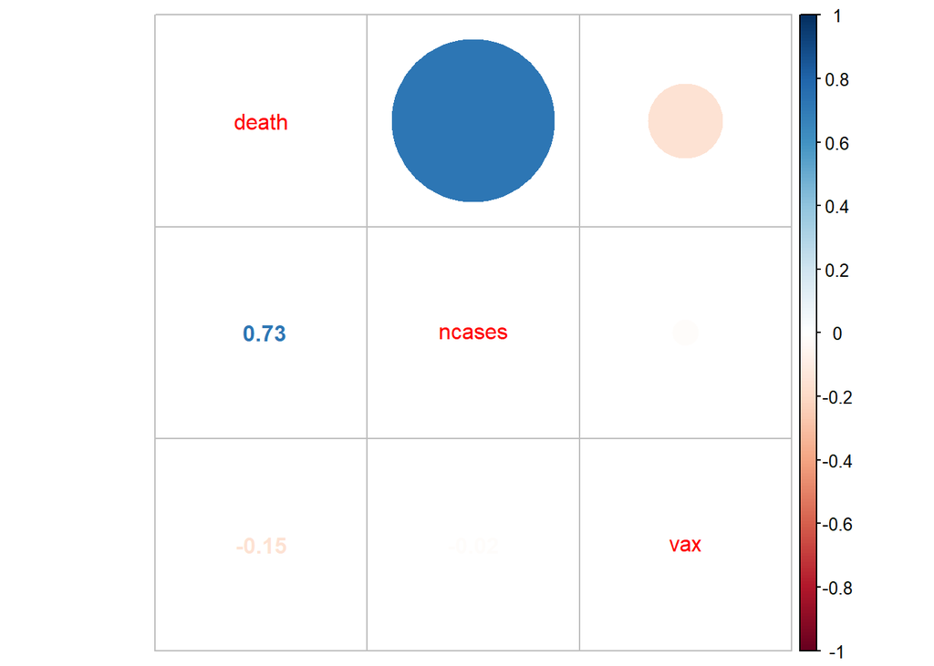

```r
c =  cor(df)
corrplot::corrplot.mixed(c,order='AOE')
```

### Observation :

- We can see that vaccinations have little to no effect on number of new cases
- New cases have a very high positive correlation with deaths
- Vaccinations have a negative correlation with death

## plots

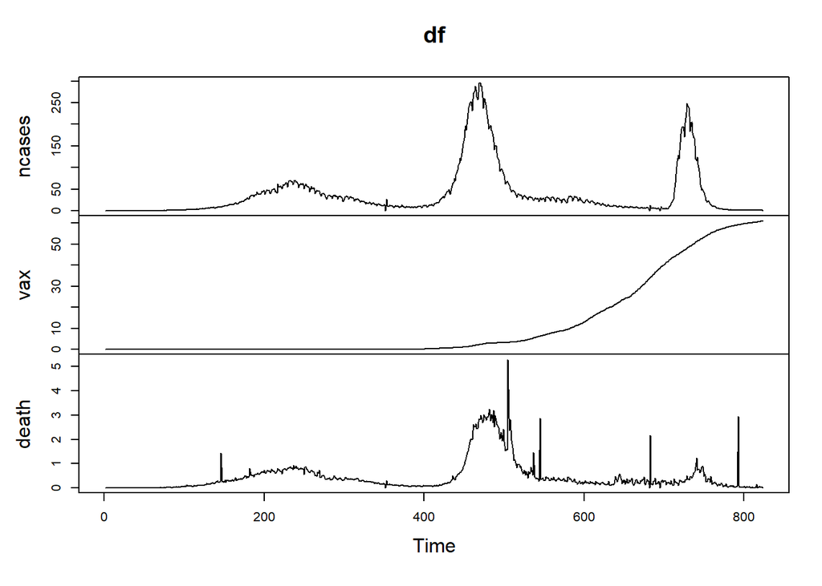

```r
plot.ts(df)
```

## Regression Model

An Explanatory model by which we intend to explain what vaccines affect the most in past using past data

```r
mdl = lm(death~vax*ncases,data = df)
summary(mdl)
```

```
##
## Call:
## lm(formula = death ~ vax * ncases, data = df)
##
## Residuals:
##     Min      1Q  Median      3Q     Max
## -1.0280 -0.1103 -0.0616  0.0299  4.5022
##
## Coefficients:
##               Estimate Std. Error t value Pr(>|t|)
## (Intercept)  1.098e-01  1.869e-02   5.875 6.15e-09 ***
## vax          1.839e-03  7.738e-04   2.376   0.0177 *
## ncases       1.080e-02  2.766e-04  39.030  < 2e-16 ***
## vax:ncases  -1.886e-04  1.113e-05 -16.950  < 2e-16 ***
## ---
## Signif. codes:  0 '***' 0.001 '**' 0.01 '*' 0.05 '.' 0.1 ' ' 1
##
## Residual standard error: 0.3789 on 820 degrees of freedom
## Multiple R-squared:  0.6635, Adjusted R-squared:  0.6623
## F-statistic:   539 on 3 and 820 DF,  p-value: < 2.2e-16
```

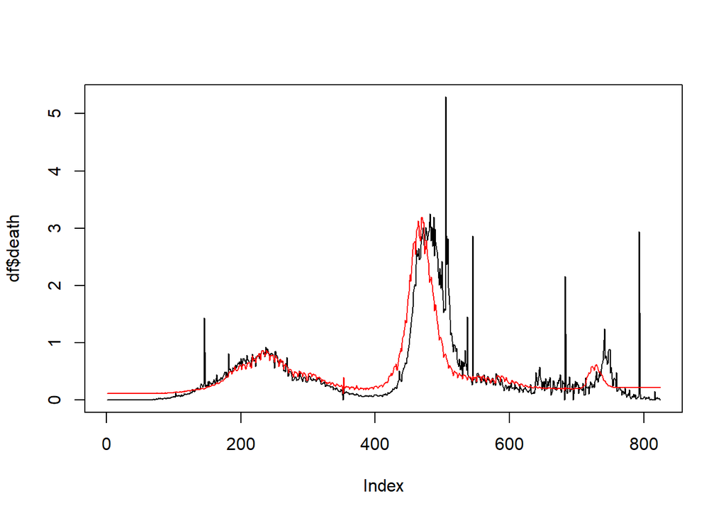

```r
d =  predict(mdl,newdata = df)
plot(df$death,type = "l")
lines(d,col="red")
```

## Auto-ARIMA Model

Implementing an Auto-ARIMA model to predict nearby cases.

For this we need to convert the dataset into a timeseries data. We initialize dates as a seq by day and attach the dataframe (dfarmima).

```r
library(forecast)
dfarima = data.frame(ncases = newCasesIndia$newCases.India)
summary(dfarima)
```

```
##      ncases
##  Min.   :  0.000
##  1st Qu.:  5.731
##  Median : 17.656
##  Mean   : 37.503
##  3rd Qu.: 38.379
##  Max.   :297.248
```

```r
set.seed(123)
inds = seq(firstcasedate,latestcasedate, by="day")
arima_ds = ts(dfarima, frequency = 365,
                 start = c(2020, as.numeric(format(inds[1],"%j"))),
                 end = c(2022, as.numeric(format(inds[821],"%j"))))
```

### Training and validation sets

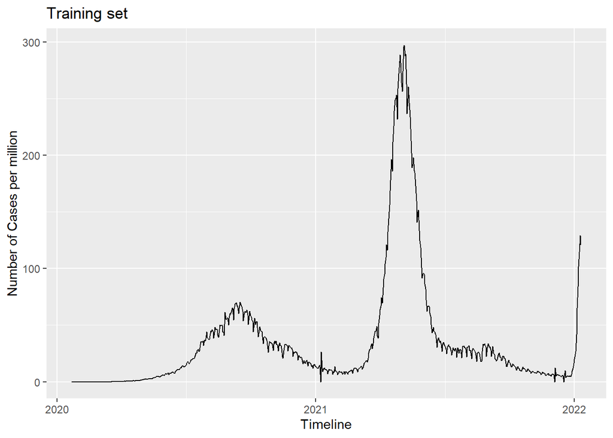

```r
training_set = window(arima_ds, start = c(2020, 22), end = c(2022, 10))
validation_set = window(arima_ds, start = c(2022, 11), end = c(2022,111 ))

autoplot(training_set, main = 'Training set',xlab = 'Timeline',ylab = 'Number of Cases per million')
```